# Estimation of the stock-recruitement parameters

## Study area

Divisions 7.e-k (Eastern English Channel and Southern Celtic Seas)

## Data

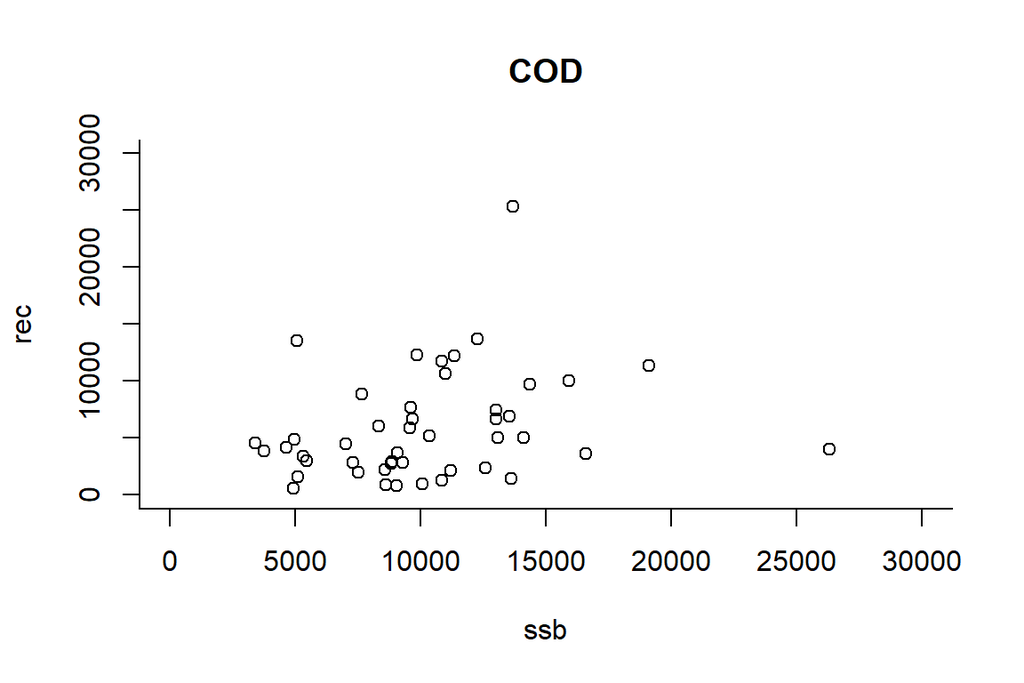

Data from the ICES Stock Assessment Graphs database http://sg.ices.dk for the period (1971 - 2017)

## Standard estimation of the S-R parameters

**The Beverton and Holt stock recruitment relationship**

\[R=\frac{\alpha B}{\beta + B} \] Where

- \(R\) : the recruitement
- \(B\) : the spawing stock biomass
- \(\alpha\) : the maximum rectrutement
- \(\beta\) : the spawing stock biomass needed to produce \(\alpha/2\)

## Standard estimation of the S-R parameters

Direct estimation of \(\alpha\) and \(\beta\) using a likelihood function

```r
LL <- function(par){
  a <- exp(par[1])
  b <- exp(par[2])
  c <- exp(par[3])

  R <- a*ssb / (b+ssb)

  ll = dlnorm(rec, meanlog = log(R)-(c^2)/2, sdlog = c, log = T)
  -sum(ll)
}

LL_opt_cod <- optim(par = log(c(15e3, 1e4, 2)),  fn = LL)
```

## Standard estimation of the S-R parameters

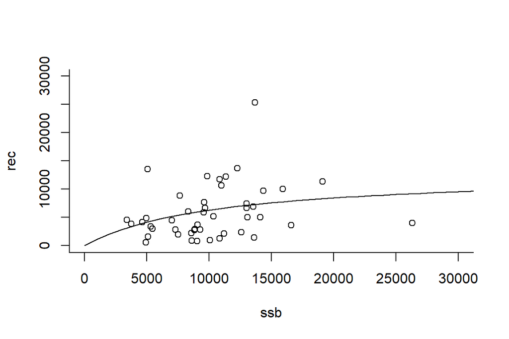

## Estimation of the S-R parameters using **the steepness h**

**The Beverton and Holt stock recruitment relationship**

\[R=\frac{B}{\alpha + \beta B} \] Where

- \(R\) : the recruitement
- \(B\) : the spawing stock biomass
- \(\alpha\) : the inverse of the initial slope of the curve
- \(\beta\) : the inverse of asymptotic recruitment

## Estimation of the S-R parameters using **the steepness h**

### \(\alpha\) and \(\beta\) parameters

\[\alpha = \frac{S_0}{R_0} \frac{1-h}{4h} \] \[\beta = \frac{5h-1}{4hR_0} \]

Where

- \(R_0\) : the recruitment when \(F=0\)
- \(h\) : the steepness parameter defined as the proportion of unfished recruitment \(R_0\) produced by 20% of unfished population fecundity or spawning biomass \(S_0\)
- \(S_0\) : the spawing stock biomass when at \(F=0\)

(*from Mangel et al. 2009*)

## Estimation of the S-R parameters using **the steepness h**

### The Beverton-Holt spawner-recruit function expressed with steepness parameter

\[ R = \frac{0.8R_0hS}{0.2S_0(1-h)+(h-0.2)S}\]

Where

- \(R\) : the recrutement
- \(R_0\) : the unfished recruitment
- \(h\) : the steepness parameter defined as the proportion of unfished recruitment \(R_0\) produced by 20% of unfished population fecundity or spawning biomass \(S_0\)
- \(S\) : the spawing stock biomass

(*from Mace and Doonan 1988*)

## Estimation of the S-R parameters using **the steepness h**

### Etimation of \(N\) by age when \(F=0\)

\[N_{a+1} = N_ae^{-M_a} \]

## Estimation of the S-R parameters using **the steepness h**

### Etimation of \(S\) by age when \(F=0\)

\[ S_0 = \sum_{a=0}^{T}N_aW_aMat_a \]

Where

- \(S_0\) : the unfished spawing biomass
- \(N_a\) : the number at age
- \(W_a\) : the weight at age
- \(Mat_a\) : the maturity at age

## Estimation of the S-R parameters using **the steepness h**

### Using a fixed value for the steepness parameter

- Estimation of \(\alpha\) and \(\beta\) using a likelihood function
- \(h=0.87\) (*from Meyers et al. 1999*)

## Estimation of the S-R parameters using **the steepness h**

### Using a fixed value for the steepness parameter

```r
## likelihood function
LL <- function(par) {

  R0 <- exp(par[1])
  c <- exp(par[2])

  M <- M # vector of natural mortality by age
  N <- rep(NA, 7)
  N[1] <- R0
  for (i in 1:6) {
    N[i+1] <- N[i]*exp(-M[i])
  }

  data$N <-N
  S <- apply(data, 1, function(x) x[2]*x[3]*x[4])
  S0 <- sum(S)

  R <- 0.8*R0*h*ssb / (0.2*S0*(1-h) + ssb*(h-0.2))

  ll = dlnorm(rec, meanlog = log(R)-(c^2)/2, sdlog = c, log = T)
  -sum(ll)
}

LL_opt <- nlminb(start = log(c(10000, 0.2)),  objective = LL)
```

## Estimation of the S-R parameters using **the steepness h**

### Using a fixed value for the steepness parameter

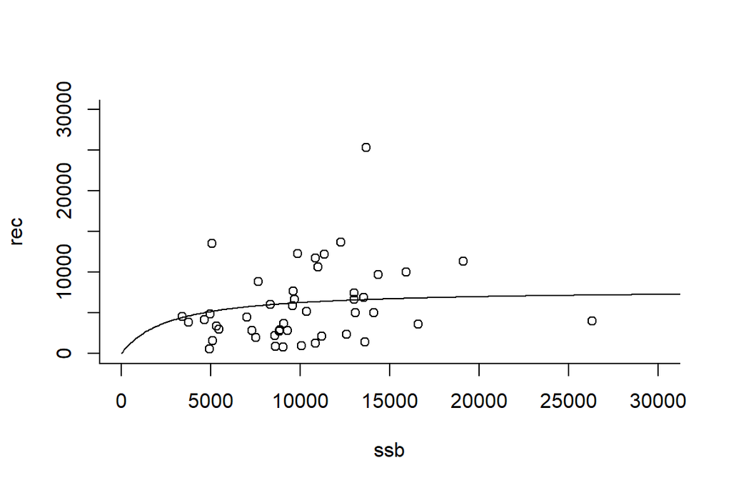

## Estimation of the S-R parameters using **the steepness h**

### Adding a prior on the steepness parameter

Estimated from (*Meyers et al. 1999*)

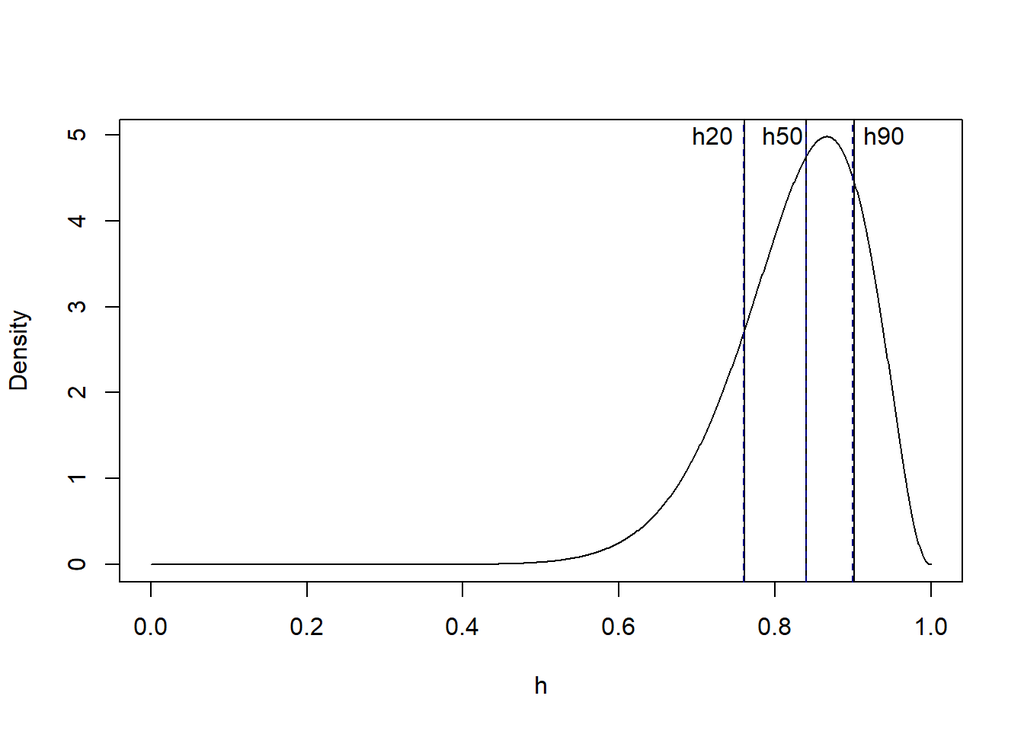

## Estimation of the S-R parameters using **the steepness h**

### Adding a prior on the steepness parameter

```r
#  adding a prior for the steepness parameter
zmed <- 0.84
z20 <- 0.76
z80 <- 0.9

## sum of square of the difference at z20 and z80
ssq <- function(alpha){
  beta <- (alpha - 1/3) / zmed - alpha + 2/3
  z20.pred <- qbeta(p = 0.2, shape1 = alpha, shape2 = beta)
  z80.pred <- qbeta(p = 0.8, shape1 = alpha, shape2 = beta)
  return((z20.pred-z20)^2 + (z80.pred-z80)^2)
}

fit <- optim(par = 2, fn = ssq, method = "Brent", lower = 1, upper = 50)

alpha.hat <- fit$par
beta.hat <- (alpha.hat - 1/3) / zmed - alpha.hat + 2/3
```

## Estimation of the S-R parameters using **the steepness h**

### Adding a prior on the steepness parameter

```r
# Likelihood function : Estimation of R0 using a prior en h
LL <- function(par) {

  # parameters to estimate
  R0 <- exp(par[1])
  sdev <- exp(par[2])
  h <- exp(par[3])

  # abundance by age class
  N <- rep(NA, 7)
  N[1] <- R0
  for (i in 1:6) {
    N[i+1] <- N[i]*exp(-M[i])
  }

  # S0
  data$N <- N
  S <- apply(data, 1, function(x) x[2]*x[3]*x[4])
  S0 <- sum(S)

  R <- 0.8*R0*h*ssb / (0.2*S0*(1-h) + ssb*(h-0.2))

  ll = dlnorm(rec, meanlog = log(R)-(sdev^2)/2, sdlog = sdev, log = T)
  llp <- ll + dbeta(h, shape1 = alpha.hat, shape2 = beta.hat) # adding the prior

  -sum(llp)
}

LL_opt <- nlminb(start = log(c(10000, 0.2, 0.8)),  objective = LL)
```

## Estimation of the S-R parameters using **the steepness h**

### Adding a prior on the steepness parameter

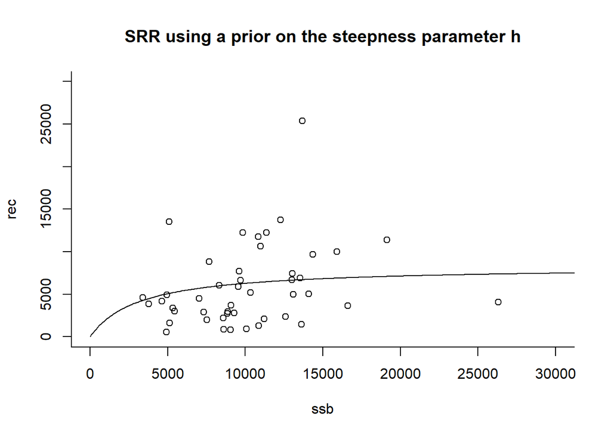

## Estimation of the S-R parameters

[figure not shown]